# Practical Machine Learning - Course Assignment

Alexander Bruns

August 2015

## Introduction

This analysis aims to determine the best model for the provided WLE dataset from http://groupware.les.inf.puc-rio.br/har.

#### Requiered Packages

- **caret**
- **ggplot2**
- **e1071**
- **randomForest**

### Data Cleaning

The training dataset is loaded from the WLE dataset from http://groupware.les.inf.puc-rio.br/har archive into R.

Then several datacleaning and EDA steps were performed. Data cleaning included the following steps:

- Identifying N/A values
  - Blanks, NA and #DIV/0 were marked as NAs
- Deleting columns which only contained NAs by using *colSums*
- Deleting columns with time information
- Separating the outcome

Deleted columns were standard deviations from the measurements and bookkeeping values, therefore **non** independent. ### Data Processing

After tidying up the data, assuring that all predictor variables are *numeric* and the outcome is a *factor* variable the data was further processed to reduce the dimensions of the data set. Firstly, **caret’s** *nearZeroVar()* was applied in order to identfy columns with zero or near zero variance. However, all columns have variance above zero.

```r
nzi<-nearZeroVar(training)
nzi
```

```
## integer(0)
```

Then colinear colmumns were identified and deleted using **caret´s** *findCorrealtion()* function.

```r
descrCorr <- cor(training)
highCorr <- findCorrelation(descrCorr, 0.90)
deleted_cols<-names(training[,highCorr])
training <- training[,-highCorr]
deleted_cols
```

```
## [1] "accel_belt_z"     "roll_belt"        "accel_belt_y"
## [4] "accel_belt_x"     "gyros_dumbbell_x" "gyros_dumbbell_z"
## [7] "gyros_arm_x"
```

### Model Building

Two models were compared in respect to their accuracy and computing time.

- Multinomial General Regression (multinom)
- CART Trees (randomForest)

#### Multinomial Regression

```r
ctrl <- trainControl(method = "cv", number = 3, allowParallel = F)
set.seed(123)
multitrain <- createDataPartition(training$outcome, p = 0.4, list = FALSE)

fullGLMmod <- train(outcome ~ ., data = training[multitrain, ], method = "multinom",
    trControl = ctrl)
```

Multinomial regression determines the probability of a certain outcome for a factor variable. However accuracy was quiet low with 0.6434849

Out-of-sample accuracy: 61.3%

```r
confusionMatrix(predict(fullGLMmod,newdata=training[-multitrain,2:46]),training[-multitrain,1])
```

```
## Confusion Matrix and Statistics
##
##           Reference
## Prediction    A    B    C    D    E
##          A 2701  396  346  209  178
##          B  141 1278  161   76  421
##          C  208  202 1039  265  241
##          D  213  150  318 1218  346
##          E   85  252  189  161  978
##
## Overall Statistics
##
##                Accuracy : 0.6128
##                  95% CI : (0.6039, 0.6216)
##     No Information Rate : 0.2844
##     P-Value [Acc > NIR] : < 2.2e-16
##
##                   Kappa : 0.5081
##  Mcnemar's Test P-Value : < 2.2e-16
##
## Statistics by Class:
##
##                      Class: A Class: B Class: C Class: D Class: E
## Sensitivity            0.8068   0.5610  0.50609   0.6314  0.45194
## Specificity            0.8660   0.9158  0.90575   0.8957  0.92850
## Pos Pred Value         0.7052   0.6153  0.53146   0.5425  0.58739
## Neg Pred Value         0.9185   0.8969  0.89671   0.9254  0.88266
## Prevalence             0.2844   0.1935  0.17440   0.1639  0.18383
## Detection Rate         0.2294   0.1086  0.08826   0.1035  0.08308
## Detection Prevalence   0.3253   0.1764  0.16607   0.1907  0.14144
## Balanced Accuracy      0.8364   0.7384  0.70592   0.7635  0.69022
```

#### RandomForest Classification

```r
RFtraining<-createDataPartition(training$outcome,p = 0.4, list = FALSE)
RF<-randomForest(outcome~.,data=training[RFtraining,],replace=T,importance=T,proximity=T,scale=F,ntree=250)
```

```r
confusionMatrix(predict(RF,newdata=training[-RFtraining,2:46]),training[-RFtraining,1])
```

```
## Confusion Matrix and Statistics
##
##           Reference
## Prediction    A    B    C    D    E
##          A 3339   33    0    0    0
##          B    8 2234   37    0    0
##          C    0    9 2005   27    3
##          D    0    1    9 1899    5
##          E    1    1    2    3 2156
##
## Overall Statistics
##
##                Accuracy : 0.9882
##                  95% CI : (0.9861, 0.9901)
##     No Information Rate : 0.2844
##     P-Value [Acc > NIR] : < 2.2e-16
##
##                   Kappa : 0.9851
##  Mcnemar's Test P-Value : NA
##
## Statistics by Class:
##
##                      Class: A Class: B Class: C Class: D Class: E
## Sensitivity            0.9973   0.9807   0.9766   0.9844   0.9963
## Specificity            0.9961   0.9953   0.9960   0.9985   0.9993
## Pos Pred Value         0.9902   0.9803   0.9809   0.9922   0.9968
## Neg Pred Value         0.9989   0.9954   0.9951   0.9970   0.9992
## Prevalence             0.2844   0.1935   0.1744   0.1639   0.1838
## Detection Rate         0.2836   0.1898   0.1703   0.1613   0.1831
## Detection Prevalence   0.2864   0.1936   0.1736   0.1626   0.1837
## Balanced Accuracy      0.9967   0.9880   0.9863   0.9915   0.9978
```

In the direct comparison the RF does a way better job to classify the outcome than the multinomial regression. Now let´s examine the impact of each classifier:

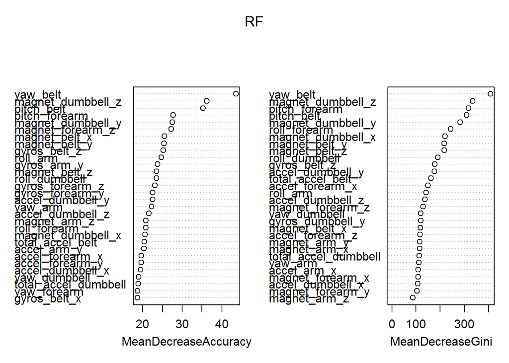

```r
varImpPlot(RF)
```

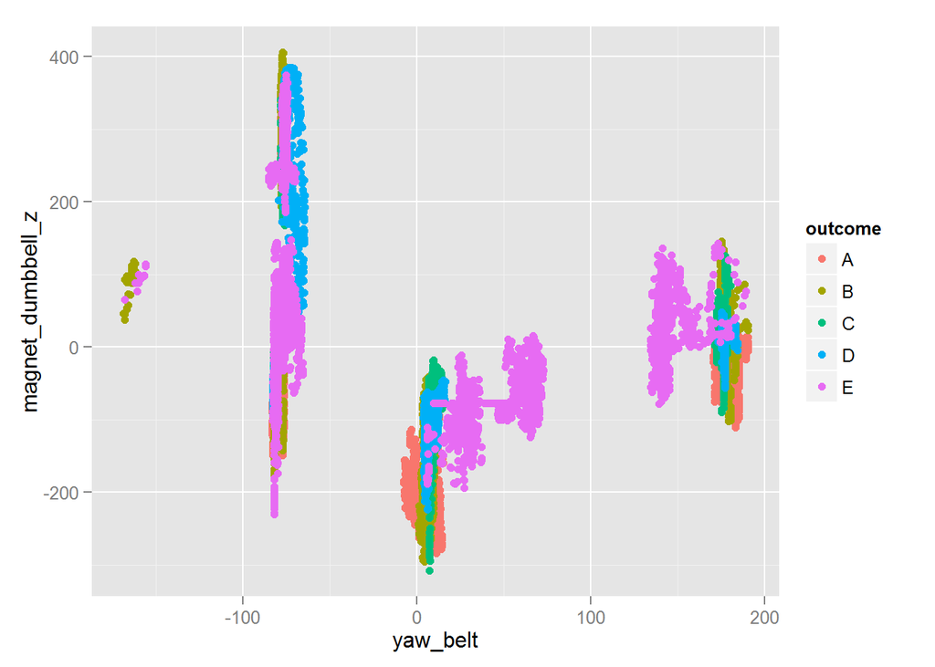

```r
qplot(yaw_belt,magnet_dumbbell_z,data=training,color=outcome)
```

### Bibliography

Velloso, E.; Bulling, A.; Gellersen, H.; Ugulino, W.; Fuks, H. **Qualitative Activity Recognition of Weight Lifting Exercises.** Proceedings of 4th International Conference in Cooperation with SIGCHI (Augmented Human ’13) . Stuttgart, Germany: ACM SIGCHI, 2013.